# Data Science Capstone Project

Daniel Thompson

2023-12-22

# 1 Introduction and learning objectives

The goal of this project is to build a predictive model for guiding investment decisions in the London housing market. This involves constructing machine learning models to predict house prices and selecting the best 200 properties for investment purposes.

1. Applying various data mining algorithms for prediction.
2. Handling and analyzing large datasets.
3. Optimizing algorithms for enhanced performance.
4. Interpreting results to understand the influence of different variables.
5. Making informed business decisions based on algorithmic predictions.

# 2 Load data

There are two sets of data, i) training data that has the actual prices ii) out of sample data that has the asking prices. We begin by loading both data sets.

```r
# Read the training and out-of-sample data.
london_house_prices_2019_training <- read.csv("training_data_assignment_with_prices.csv")
london_house_prices_2019_out_of_sample <- read.csv("test_data_assignment.csv")

# Convert string dates to Date objects and convert character columns to factors for consistency in data types.
london_house_prices_2019_training <- london_house_prices_2019_training %>% mutate(date = as.Date(date)) %>% mutate_if(is.character, as.factor)
london_house_prices_2019_out_of_sample <- london_house_prices_2019_out_of_sample %>% mutate(date = as.Date(date)) %>% mutate_if(is.character, as.factor)

# Quick examination of the structure of datasets.
str(london_house_prices_2019_training)
```

```
## 'data.frame':    13998 obs. of  37 variables:
##  $ ID                          : int  2 3 4 5 7 8 9 10 11 12 ...
##  $ date                        : Date, format: "2019-11-01" "2019-08-08" ...
##  $ postcode                    : Factor w/ 12635 levels "BR1 1AB","BR1 1LR",..: 10897 11027 11264 2031 11241 11066 421 9594 9444 873 ...
##  $ property_type               : Factor w/ 4 levels "D","F","S","T": 2 2 3 2 3 2 1 4 4 2 ...
##  $ whether_old_or_new          : Factor w/ 2 levels "N","Y": 1 1 1 1 1 1 1 1 1 1 ...
##  $ freehold_or_leasehold       : Factor w/ 2 levels "F","L": 2 2 1 2 1 2 1 1 1 2 ...
##  $ address1                    : Factor w/ 2825 levels "1","1 - 2","1 - 3",..: 2503 792 253 789 569 234 264 418 5 274 ...
##  $ address2                    : Factor w/ 434 levels "1","10","101",..: 372 NA NA NA NA NA NA NA NA NA ...
##  $ address3                    : Factor w/ 8543 levels "ABBERTON WALK",..: 6990 6821 3715 2492 4168 2879 3620 5251 6045 6892 ...
##  $ town                        : Factor w/ 133 levels "ABBEY WOOD","ACTON",..: NA NA NA 78 NA NA NA NA NA NA ...
##  $ local_aut                   : Factor w/ 69 levels "ASHFORD","BARKING",..: 36 46 24 36 24 46 65 36 36 17 ...
##  $ county                      : Factor w/ 33 levels "BARKING AND DAGENHAM",..: 22 27 18 25 18 27 5 27 32 8 ...
##  $ postcode_short              : Factor w/ 247 levels "BR1","BR2","BR3",..: 190 194 198 28 198 194 4 169 167 8 ...
##  $ current_energy_rating       : Factor w/ 6 levels "B","C","D","E",..: 4 3 3 4 3 2 4 3 4 2 ...
```

[output cut: 23 more lines]

```r
str(london_house_prices_2019_out_of_sample)
```

```
## 'data.frame':    1999 obs. of  37 variables:
##  $ ID                          : int  14434 12562 8866 10721 1057 1527 13961 12108 9363 1155 ...
##  $ date                        : Date, format: NA NA ...
##  $ postcode                    : logi  NA NA NA NA NA NA ...
##  $ property_type               : Factor w/ 4 levels "D","F","S","T": 1 2 2 3 4 3 2 3 2 4 ...
##  $ whether_old_or_new          : Factor w/ 2 levels "N","Y": 1 1 1 1 1 1 1 1 1 1 ...
##  $ freehold_or_leasehold       : Factor w/ 2 levels "F","L": 1 2 2 1 1 1 2 1 2 1 ...
##  $ address1                    : logi  NA NA NA NA NA NA ...
##  $ address2                    : logi  NA NA NA NA NA NA ...
##  $ address3                    : logi  NA NA NA NA NA NA ...
##  $ town                        : Factor w/ 54 levels "ACTON","ADDISCOMBE",..: NA NA NA NA NA NA NA NA NA NA ...
##  $ local_aut                   : logi  NA NA NA NA NA NA ...
##  $ county                      : logi  NA NA NA NA NA NA ...
##  $ postcode_short              : Factor w/ 221 levels "BR1","BR2","BR3",..: 82 50 37 52 214 150 159 115 175 126 ...
##  $ current_energy_rating       : Factor w/ 6 levels "B","C","D","E",..: 3 2 3 3 4 4 4 3 4 3 ...
```

[output cut: 23 more lines]

```r
# Check for missing values in both datasets.
skimr::skim(london_house_prices_2019_training)
```

Data summary

| Name | london_house_prices_2019_… |
| --- | --- |
| Number of rows | 13998 |
| Number of columns | 37 |
| _______________________ |  |
| Column type frequency: |  |
| Date | 1 |
| factor | 18 |
| numeric | 18 |
| ________________________ |  |
| Group variables | None |

**Variable type: Date**

| skim_variable | n_missing | complete_rate | min | max | median | n_unique |
| --- | --- | --- | --- | --- | --- | --- |
| date | 0 | 1 | 2019-01-02 | 2019-12-30 | 2019-07-22 | 263 |

**Variable type: factor**

| skim_variable | n_missing | complete_rate | ordered | n_unique | top_counts |
| --- | --- | --- | --- | --- | --- |
| postcode | 0 | 1.00 | FALSE | 12635 | E11: 5, BR1: 4, CR0: 4, E17: 4 |
| property_type | 0 | 1.00 | FALSE | 4 | F: 5402, T: 4999, S: 2780, D: 817 |
| whether_old_or_new | 0 | 1.00 | FALSE | 2 | N: 13990, Y: 8 |
| freehold_or_leasehold | 0 | 1.00 | FALSE | 2 | F: 8457, L: 5541 |
| address1 | 0 | 1.00 | FALSE | 2825 | 3: 220, 7: 212, 4: 204, 12: 197 |
| address2 | 10812 | 0.23 | FALSE | 434 | FLA: 218, FLA: 214, FLA: 213, FLA: 160 |
| address3 | 0 | 1.00 | FALSE | 8543 | LON: 25, GRE: 24, THE: 23, HIG: 21 |
| town | 13384 | 0.04 | FALSE | 133 | WAL: 35, CHE: 33, STR: 27, CHI: 24 |
| local_aut | 0 | 1.00 | FALSE | 69 | LON: 7512, ROM: 396, BRO: 277, CRO: 243 |
| county | 0 | 1.00 | FALSE | 33 | BRO: 861, CRO: 729, WAN: 702, HAV: 672 |
| postcode_short | 0 | 1.00 | FALSE | 247 | CR0: 243, SW1: 204, E17: 193, SW1: 187 |
| current_energy_rating | 0 | 1.00 | FALSE | 6 | D: 7075, C: 3488, E: 2646, B: 361 |
| windows_energy_eff | 0 | 1.00 | FALSE | 5 | Ave: 7819, Goo: 3244, Ver: 1698, Poo: 1231 |
| tenure | 0 | 1.00 | FALSE | 3 | own: 11236, ren: 2503, ren: 259 |
| nearest_station | 0 | 1.00 | FALSE | 592 | rom: 201, cha: 103, bex: 99, har: 96 |
| water_company | 0 | 1.00 | FALSE | 5 | Tha: 10471, Aff: 1577, Ess: 1154, SES: 792 |
| district | 0 | 1.00 | FALSE | 33 | Cro: 925, Bro: 843, Hav: 681, Bex: 603 |
| type_of_closest_station | 0 | 1.00 | FALSE | 3 | rai: 6512, tub: 4711, lig: 2775 |

**Variable type: numeric**

| skim_variable | n_missing | complete_rate | mean | sd | p0 | p25 | p50 | p75 | p100 | hist |
| --- | --- | --- | --- | --- | --- | --- | --- | --- | --- | --- |
| ID | 0 | 1 | 8003.94 | 4622.57 | 2.00 | 4004.50 | 8015.50 | 12018.75 | 1.5996e+04 | ▇▇▇▇▇ |
| total_floor_area | 0 | 1 | 92.55 | 45.08 | 21.00 | 64.00 | 83.00 | 108.00 | 4.8000e+02 | ▇▂▁▁▁ |
| number_habitable_rooms | 0 | 1 | 4.31 | 1.66 | 1.00 | 3.00 | 4.00 | 5.00 | 1.4000e+01 | ▆▇▁▁▁ |
| co2_emissions_current | 0 | 1 | 4.25 | 2.39 | 0.10 | 2.70 | 3.80 | 5.20 | 4.4000e+01 | ▇▁▁▁▁ |
| co2_emissions_potential | 0 | 1 | 2.22 | 1.44 | -0.50 | 1.30 | 1.80 | 2.70 | 2.0500e+01 | ▇▁▁▁▁ |
| energy_consumption_current | 0 | 1 | 262.98 | 93.42 | 12.00 | 202.00 | 249.00 | 308.00 | 1.2960e+03 | ▇▅▁▁▁ |
| energy_consumption_potential | 0 | 1 | 141.38 | 78.06 | -49.00 | 89.00 | 122.00 | 167.00 | 1.0230e+03 | ▇▂▁▁▁ |
| latitude | 0 | 1 | 51.49 | 0.08 | 51.30 | 51.43 | 51.49 | 51.56 | 5.1680e+01 | ▂▇▇▇▂ |
| longitude | 0 | 1 | -0.11 | 0.16 | -0.49 | -0.21 | -0.11 | 0.00 | 2.9000e-01 | ▂▅▇▅▂ |
| population | 69 | 1 | 83.74 | 43.71 | 1.00 | 52.00 | 79.00 | 109.00 | 5.1000e+02 | ▇▃▁▁▁ |
| altitude | 0 | 1 | 36.57 | 26.01 | 0.00 | 16.00 | 32.00 | 51.00 | 2.3900e+02 | ▇▃▁▁▁ |
| london_zone | 0 | 1 | 3.76 | 1.43 | 1.00 | 3.00 | 4.00 | 5.00 | 7.0000e+00 | ▇▇▇▆▅ |
| average_income | 0 | 1 | 55334.70 | 8454.23 | 36000.00 | 49400.00 | 54600.00 | 60600.00 | 8.5200e+04 | ▃▇▆▂▁ |
| price | 0 | 1 | 593790.93 | 519158.10 | 77000.00 | 351000.00 | 460000.00 | 650000.00 | 1.0800e+07 | ▇▁▁▁▁ |
| num_tube_lines | 0 | 1 | 0.44 | 0.74 | 0.00 | 0.00 | 0.00 | 1.00 | 6.0000e+00 | ▇▁▁▁▁ |
| num_rail_lines | 0 | 1 | 0.58 | 0.51 | 0.00 | 0.00 | 1.00 | 1.00 | 2.0000e+00 | ▆▁▇▁▁ |
| num_light_rail_lines | 0 | 1 | 0.24 | 0.43 | 0.00 | 0.00 | 0.00 | 0.00 | 1.0000e+00 | ▇▁▁▁▂ |
| distance_to_station | 0 | 1 | 0.65 | 0.40 | 0.00 | 0.37 | 0.57 | 0.84 | 5.6100e+00 | ▇▁▁▁▁ |

```r
skimr::skim(london_house_prices_2019_out_of_sample)
```

Data summary

| Name | london_house_prices_2019_… |
| --- | --- |
| Number of rows | 1999 |
| Number of columns | 37 |
| _______________________ |  |
| Column type frequency: |  |
| Date | 1 |
| factor | 12 |
| logical | 6 |
| numeric | 18 |
| ________________________ |  |
| Group variables | None |

**Variable type: Date**

| skim_variable | n_missing | complete_rate | min | max | median | n_unique |
| --- | --- | --- | --- | --- | --- | --- |
| date | 1999 | 0 | Inf | -Inf | NA | 0 |

**Variable type: factor**

| skim_variable | n_missing | complete_rate | ordered | n_unique | top_counts |
| --- | --- | --- | --- | --- | --- |
| property_type | 0 | 1.00 | FALSE | 4 | F: 785, T: 688, S: 395, D: 131 |
| whether_old_or_new | 0 | 1.00 | FALSE | 2 | N: 1998, Y: 1 |
| freehold_or_leasehold | 0 | 1.00 | FALSE | 2 | F: 1209, L: 790 |
| town | 1916 | 0.04 | FALSE | 54 | CHE: 7, WAL: 7, BLA: 3, FOR: 3 |
| postcode_short | 0 | 1.00 | FALSE | 221 | SW1: 40, CR0: 39, E17: 37, SW1: 28 |
| current_energy_rating | 0 | 1.00 | FALSE | 6 | D: 980, C: 514, E: 399, F: 52 |
| windows_energy_eff | 0 | 1.00 | FALSE | 5 | Ave: 1118, Goo: 475, Ver: 233, Poo: 172 |
| tenure | 0 | 1.00 | FALSE | 3 | own: 1642, ren: 322, ren: 35 |
| nearest_station | 0 | 1.00 | FALSE | 494 | orp: 22, sid: 22, rom: 20, bex: 17 |
| water_company | 0 | 1.00 | FALSE | 4 | Tha: 1495, Aff: 238, Ess: 149, SES: 117 |
| district | 0 | 1.00 | FALSE | 32 | Cro: 136, Bro: 120, Bex: 93, Hav: 93 |
| type_of_closest_station | 0 | 1.00 | FALSE | 3 | rai: 971, tub: 662, lig: 366 |

**Variable type: logical**

| skim_variable | n_missing | complete_rate | mean | count |
| --- | --- | --- | --- | --- |
| postcode | 1999 | 0 | NaN | : |
| address1 | 1999 | 0 | NaN | : |
| address2 | 1999 | 0 | NaN | : |
| address3 | 1999 | 0 | NaN | : |
| local_aut | 1999 | 0 | NaN | : |
| county | 1999 | 0 | NaN | : |

**Variable type: numeric**

| skim_variable | n_missing | complete_rate | mean | sd | p0 | p25 | p50 | p75 | p100 | hist |
| --- | --- | --- | --- | --- | --- | --- | --- | --- | --- | --- |
| ID | 0 | 1 | 7964.38 | 4587.52 | 1.00 | 3951.00 | 7911.00 | 11821.50 | 1.5997e+04 | ▇▇▇▇▇ |
| total_floor_area | 0 | 1 | 94.36 | 49.05 | 24.00 | 63.00 | 82.00 | 111.00 | 4.6700e+02 | ▇▂▁▁▁ |
| number_habitable_rooms | 0 | 1 | 4.37 | 1.76 | 1.00 | 3.00 | 4.00 | 5.00 | 1.2000e+01 | ▇▇▃▁▁ |
| co2_emissions_current | 0 | 1 | 4.33 | 2.59 | 0.50 | 2.70 | 3.80 | 5.30 | 2.2000e+01 | ▇▃▁▁▁ |
| co2_emissions_potential | 0 | 1 | 2.30 | 1.55 | 0.10 | 1.30 | 1.90 | 2.80 | 1.6000e+01 | ▇▂▁▁▁ |
| energy_consumption_current | 0 | 1 | 264.11 | 95.68 | 61.00 | 199.00 | 250.00 | 308.50 | 8.6700e+02 | ▅▇▁▁▁ |
| energy_consumption_potential | 0 | 1 | 143.93 | 79.07 | 1.00 | 92.00 | 123.00 | 169.50 | 7.3200e+02 | ▇▃▁▁▁ |
| latitude | 0 | 1 | 51.49 | 0.08 | 51.30 | 51.43 | 51.49 | 51.56 | 5.1680e+01 | ▂▇▇▇▂ |
| longitude | 0 | 1 | -0.11 | 0.16 | -0.48 | -0.21 | -0.11 | 0.00 | 2.7000e-01 | ▂▆▇▅▂ |
| population | 7 | 1 | 83.06 | 44.35 | 4.00 | 52.00 | 78.00 | 107.00 | 6.2000e+02 | ▇▂▁▁▁ |
| altitude | 0 | 1 | 36.70 | 26.07 | 1.00 | 17.00 | 31.00 | 50.00 | 1.7500e+02 | ▇▅▁▁▁ |
| london_zone | 0 | 1 | 3.78 | 1.42 | 1.00 | 3.00 | 4.00 | 5.00 | 6.0000e+00 | ▆▇▆▆▅ |
| average_income | 0 | 1 | 55541.92 | 8433.91 | 36500.00 | 49800.00 | 54700.00 | 60900.00 | 8.5200e+04 | ▃▇▆▂▁ |
| num_tube_lines | 0 | 1 | 0.44 | 0.75 | 0.00 | 0.00 | 0.00 | 1.00 | 6.0000e+00 | ▇▁▁▁▁ |
| num_rail_lines | 0 | 1 | 0.59 | 0.51 | 0.00 | 0.00 | 1.00 | 1.00 | 2.0000e+00 | ▆▁▇▁▁ |
| num_light_rail_lines | 0 | 1 | 0.22 | 0.42 | 0.00 | 0.00 | 0.00 | 0.00 | 1.0000e+00 | ▇▁▁▁▂ |
| distance_to_station | 0 | 1 | 0.65 | 0.39 | 0.01 | 0.38 | 0.57 | 0.83 | 3.1800e+00 | ▇▅▁▁▁ |
| asking_price | 0 | 1 | 626550.78 | 676909.46 | 83000.00 | 349500.00 | 473000.00 | 669500.00 | 1.6513e+07 | ▇▁▁▁▁ |

```r
# Remove columns with low completion rate to focus on more reliable data.
london_house_prices_2019_training <- subset(london_house_prices_2019_training, select = -c(address2, town))
london_house_prices_2019_out_of_sample <- subset(london_house_prices_2019_out_of_sample, select = -c(address2, town))

# Filter out rows with missing population data to maintain data integrity.
london_house_prices_2019_training <- london_house_prices_2019_training %>% filter(!is.na(population))
london_house_prices_2019_out_of_sample <- london_house_prices_2019_out_of_sample %>% filter(!is.na(population))
```

```r
# Set seed for reproducibility
set.seed(123)

# Loading the rsample package for data splitting
library(rsample)

# Splitting the data into training and testing sets with 75% of data for training
train_test_split <- initial_split(london_house_prices_2019_training, prop = 0.75)
train_data <- training(train_test_split)
test_data <- testing(train_test_split)

# Harmonizing 'postcode_short' levels across training and out-of-sample datasets
common_postcode_levels <- union(levels(train_data$postcode_short), levels(london_house_prices_2019_out_of_sample$postcode_short))
train_data$postcode_short <- factor(train_data$postcode_short, levels = common_postcode_levels)
london_house_prices_2019_out_of_sample$postcode_short <- factor(london_house_prices_2019_out_of_sample$postcode_short, levels = common_postcode_levels)

# Addressing high cardinality in 'nearest_station' variable across all datasets
# Combining station data from all datasets for frequency analysis
all_stations <- c(train_data$nearest_station, test_data$nearest_station, london_house_prices_2019_out_of_sample$nearest_station)

# Creating a frequency table to identify rare stations
station_freq <- table(all_stations)

# Identifying stations with fewer than two occurrences
rare_stations <- names(station_freq[station_freq < 2])

# Replacing rare stations with 'Other' in each dataset
train_data$nearest_station <- ifelse(train_data$nearest_station %in% rare_stations, 'Other', as.character(train_data$nearest_station))
test_data$nearest_station <- ifelse(test_data$nearest_station %in% rare_stations, 'Other', as.character(test_data$nearest_station))
london_house_prices_2019_out_of_sample$nearest_station <- ifelse(london_house_prices_2019_out_of_sample$nearest_station %in% rare_stations, 'Other', as.character(london_house_prices_2019_out_of_sample$nearest_station))

# Ensuring consistency of 'nearest_station' levels across all datasets
all_unique_stations <- unique(c(train_data$nearest_station, test_data$nearest_station, london_house_prices_2019_out_of_sample$nearest_station))
train_data$nearest_station <- factor(train_data$nearest_station, levels = all_unique_stations)
test_data$nearest_station <- factor(test_data$nearest_station, levels = all_unique_stations)
london_house_prices_2019_out_of_sample$nearest_station <- factor(london_house_prices_2019_out_of_sample$nearest_station, levels = all_unique_stations)
```

# 3 Visualize data

Now we visualise and explore the data.

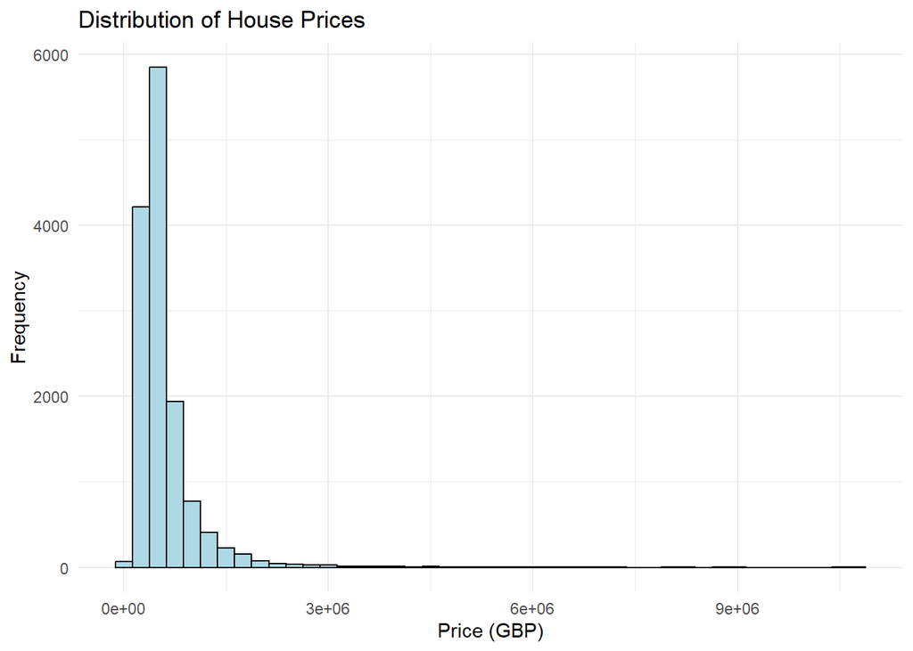

```r
# Histogram of house prices
ggplot(data = london_house_prices_2019_training, aes(x = price)) +
  geom_histogram(binwidth = 250000, fill = "lightblue", color = "black") +
  labs(title = "Distribution of House Prices", x = "Price (GBP)", y = "Frequency") +
  theme_minimal()
```

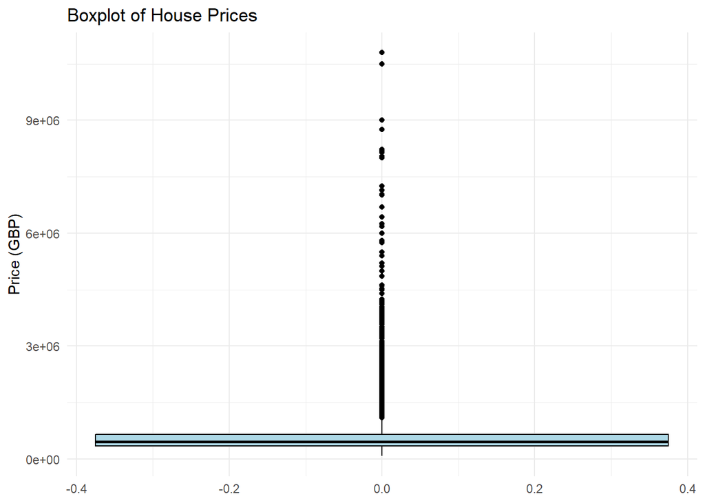

```r
# Boxplot for house prices
ggplot(london_house_prices_2019_training, aes(y = price)) +
  geom_boxplot(fill = "lightblue", color = "black") +
  labs(title = "Boxplot of House Prices", y = "Price (GBP)")+
  theme_minimal()
```

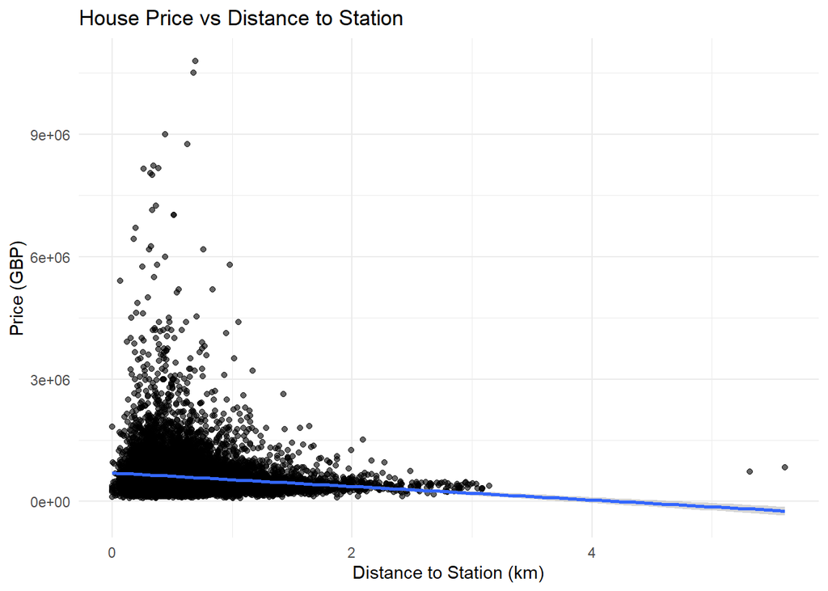

```r
# Scatter plot for price vs distance to station
ggplot(london_house_prices_2019_training, aes(x = distance_to_station, y = price)) +
  geom_point(alpha = 0.6) +
  geom_smooth(method=lm)+
  labs(title = "House Price vs Distance to Station", x = "Distance to Station (km)", y = "Price (GBP)")+
  theme_minimal()+
  scale_color_brewer(palette = "Set1")
```

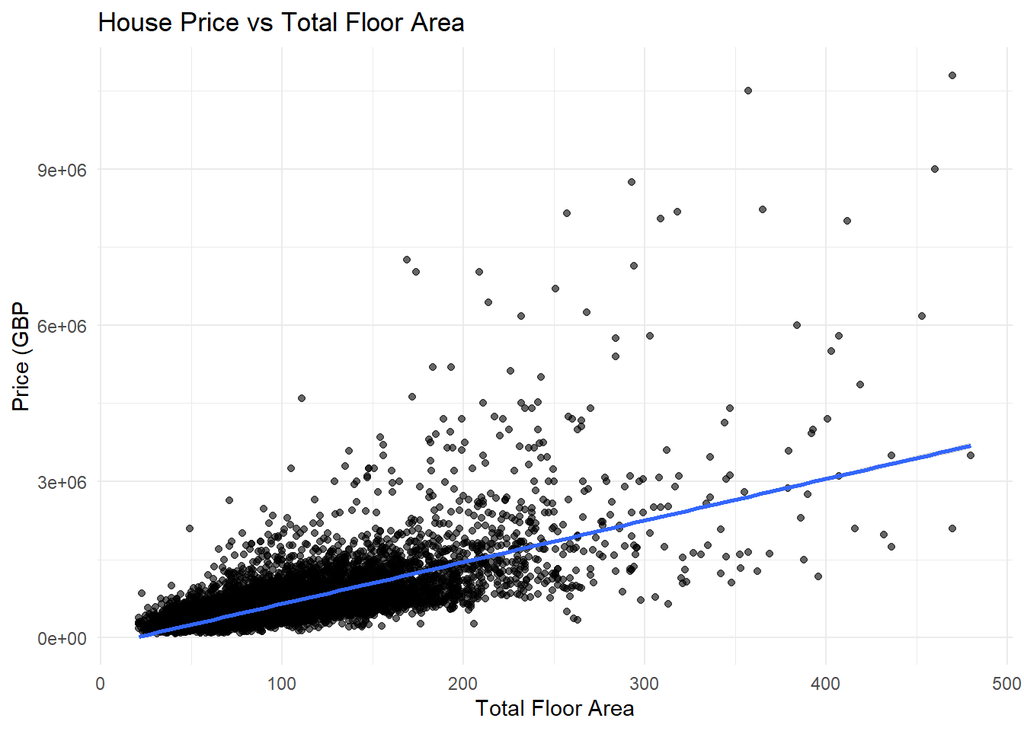

```r
# Scatter plot for price vs total floor area
ggplot(london_house_prices_2019_training, aes(x = total_floor_area, y = price)) +
  geom_point(alpha = 0.6) +
  geom_smooth(method=lm)+
  labs(title = "House Price vs Total Floor Area", x = "Total Floor Area", y = "Price (GBP")+
  theme_minimal()+
  scale_color_brewer(palette = "Set1")
```

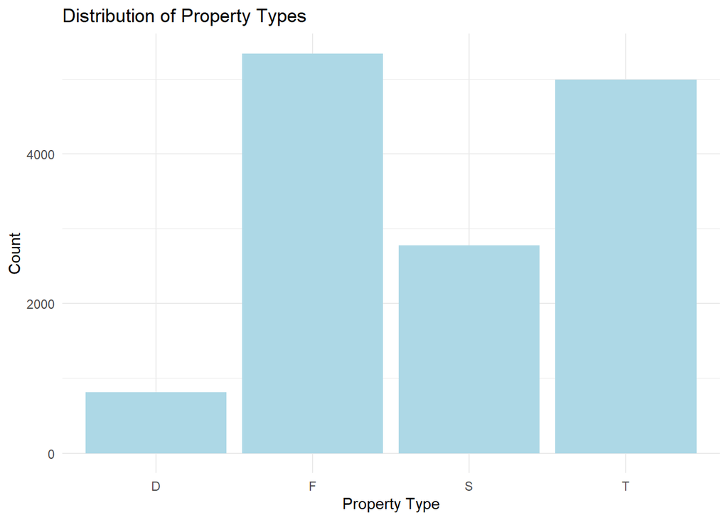

```r
# Bar plot for property types
ggplot(london_house_prices_2019_training, aes(x = property_type)) +
  geom_bar(fill = "lightblue") +
  labs(title = "Distribution of Property Types", x = "Property Type", y = "Count")+
  theme_minimal()+
  scale_color_brewer(palette = "Set1")
```

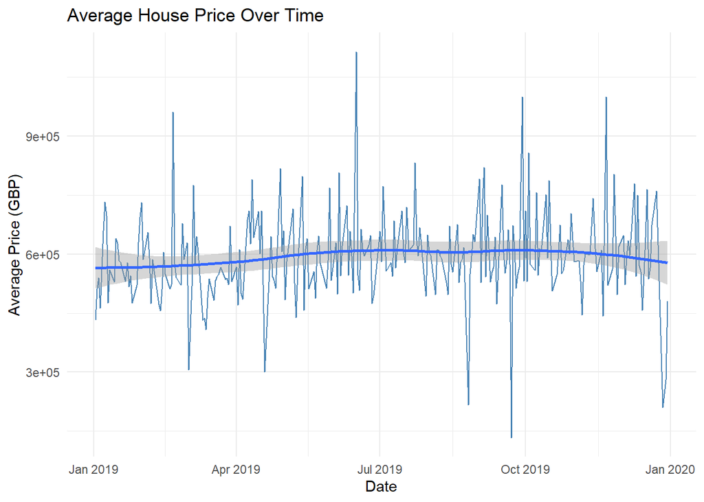

```r
# Time series plot of average house price over time
london_house_prices_2019_training %>%
  group_by(date) %>%
  summarise(avg_price=mean(price,na.rm=TRUE)) %>%
  ggplot(aes(x = date, y = avg_price)) +
  geom_line(color = "steelblue") +
  geom_smooth()+
  labs(title = "Average House Price Over Time", x = "Date", y = "Average Price (GBP)")+
  theme_minimal()+
  scale_color_brewer(palette = "Set1")
```

Comments:

From our first visualisation, we can see that the distribution of house prices is positively skewed, with most houses being prices between £250,000 and £750,000. The skew of this distribution indicates that there are a lot of outliers. To visualise the outliers, we create a boxplot. From the boxplot, we can see that there are indeed many outliers, with some houses holding incredibly high value.

From these visualisations, we can make a decision on how we handle outliers. We decide to keep the outliers in this analysis since they are plentiful, and to ensure that the models make valid/reliable predictions on extreme values in the out of sample test.

Now we begin to visualise whether any variables have correlation with the price of houses using a few scatter plots. From our House Price vs Distance to Station plot, we see a negative trend, indicating that as distance to station increases, we see a fall in the house prices, perhaps indicating that housing away from stations are less desirable. From our second scatter plot, we see that as total floor area increases, house prices also increases, but it also seems that so does variation. Perhaps, there is some interaction between floor space and another variable which causes the increase in variation.

Then, we see which housing types are the most common. We see that Flats and Terraced houses are the most common property type in London. Finally, in our last plot we see the daily average house price over time. This plot confirms that there is a relatively steady trend during the period that we are analysing house prices. This already brings forth some uncertainty surrounding the robustness of the model in a more volatile housing market. The model should be stress tested before being used in these types of environments.

Now we create a correlation table between prices and the other continuous variables.

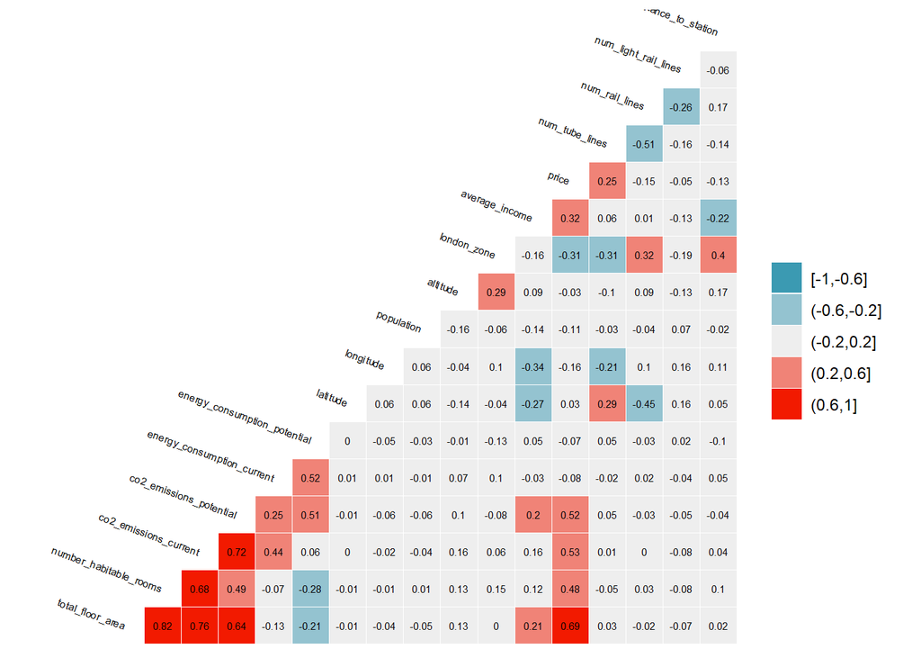

```r
# produce a correlation table using GGally::ggcor()

library("GGally")
london_house_prices_2019_training %>%
  select(-ID) %>% #keep Y variable last
  ggcorr(method = c("pairwise", "pearson"), layout.exp = 2,label_round=2, label = TRUE,label_size = 2,hjust = 1,nbreaks = 5,size = 2,angle = -20)
```

From the correlation table, we see that there are a few variables which we should explore. Firstly, despite having weak correlation with the price, we will explore how well num_tube_lines, average_income, and london_zone explain and help us predict house prices. Furthermore, we see that co2_emissions_potential, co2_emissions_current, and num_habitable_rooms have medium correlation, and total_floor_area has strong correlation with the house price. Although these variables should be explored, we should proceed with caution since there is colinearity between them.

We also see that the most correlated variable is total_floor_area, with a correlation of 0.69. Since this variable is the most correlated, we will focus on this for feature engineering. For our models, I add an interaction variable between the total_floor_area and the postcode_short variables. My intuition for this is that the price of each square meter of floor area changes between postcodes, since some postcodes may inherently be more valuable, so this interaction variable may provide some information. Furthermore, I decide to add a polynomial term for total_floor_area, to account for any non-linear relationships between this and the price.

# 4 Further Preprocessing

Upon further inspection of the out of sample dataset, we see that we do not have access to all of the same variables that we have in the training data. These variables are: postcode, address1, address3, local_aut, county, and data. I decide to remove these from the training data.

```r
# We remove these from the training data.
train_data <- train_data %>%
  select(
    -postcode,
    -address1,
    -address3,
    -local_aut,
    -county,
    -date
  )

#We remove these from the testing data.
test_data <- test_data %>%
  select(
    -postcode,
    -address1,
    -address3,
    -local_aut,
    -county,
    -date
  )
```

# 5 Fit a linear regression model

I begin by building a linear model with the most significant features, as well as the interaction variable and polynomial variable previously discussed.

```r
# Setting a seed for reproducibility of results
set.seed(123)

# Defining control settings for cross-validation
control <- trainControl(
    method = "cv",        # Using cross-validation
    number = 5,           # Number of folds in cross-validation
    verboseIter = TRUE    # Output progress during training
)

# Training the linear regression model
# Including interaction and polynomial terms for more nuanced model fitting
model1_lm <- train(
     price ~ freehold_or_leasehold + property_type + total_floor_area +
     number_habitable_rooms + co2_emissions_potential + energy_consumption_potential + windows_energy_eff + longitude + london_zone + average_income + tenure + postcode_short + postcode_short:total_floor_area + poly(total_floor_area, 2),
    data = train_data,
    method = "lm",        # Specifying linear model
    trControl = control   # Applying the control settings
)
# Limiting the max print output for a concise summary
options(max.print = 20)
# Displaying the summary of the trained model
summary(model1_lm)
```

```
##
## Call:
## lm(formula = .outcome ~ ., data = dat)
##
## Residuals:
##      Min       1Q   Median       3Q      Max
## -3179073   -51738      188    49062  3242809
##
## Coefficients: (23 not defined because of singularities)
##                                         Estimate Std. Error t value Pr(>|t|)
## (Intercept)                            1.215e+05  4.803e+04   2.530 0.011407
## freehold_or_leaseholdL                -6.707e+04  1.338e+04  -5.012 5.48e-07
## property_typeF                        -1.835e+05  1.587e+04 -11.559  < 2e-16
## property_typeS                        -1.127e+05  8.779e+03 -12.832  < 2e-16
##
## (Intercept)                           *
## freehold_or_leaseholdL                ***
## property_typeF                        ***
## property_typeS                        ***
##  [ reached getOption("max.print") -- omitted 510 rows ]
## ---
## Signif. codes:  0 '***' 0.001 '**' 0.01 '*' 0.05 '.' 0.1 ' ' 1
##
## Residual standard error: 169900 on 9955 degrees of freedom
## Multiple R-squared:  0.9038, Adjusted R-squared:  0.8991
## F-statistic: 190.9 on 490 and 9955 DF,  p-value: < 2.2e-16
```

In the linear regression model, the inclusion of interaction terms and polynomial variables significantly enhances the model’s ability to capture the complexities and nuances in the data, which are not always apparent through standard linear relationships.

- **Interaction Term (total_floor_area:postcode_short):** This interaction term helps to model the relationship between the total floor area of a property and its location (as indicated by the postcode). Since property values can vary greatly across different postcodes, even for similar-sized properties, this interaction term allows the model to capture these variations. It essentially allows the model to learn that the impact of floor area on price is not uniform across all locations but varies depending on where the property is situated.
- **Polynomial Term (poly(total_floor_area, 2)):** The inclusion of a polynomial term for total floor area addresses the possibility of a non-linear relationship between floor area and price. In many real estate markets, larger properties do not simply scale linearly in price with an increase in size. The polynomial term allows the model to capture such non-linear effects, such as diminishing returns on price with increasing size or other complex patterns that a linear term alone cannot capture.

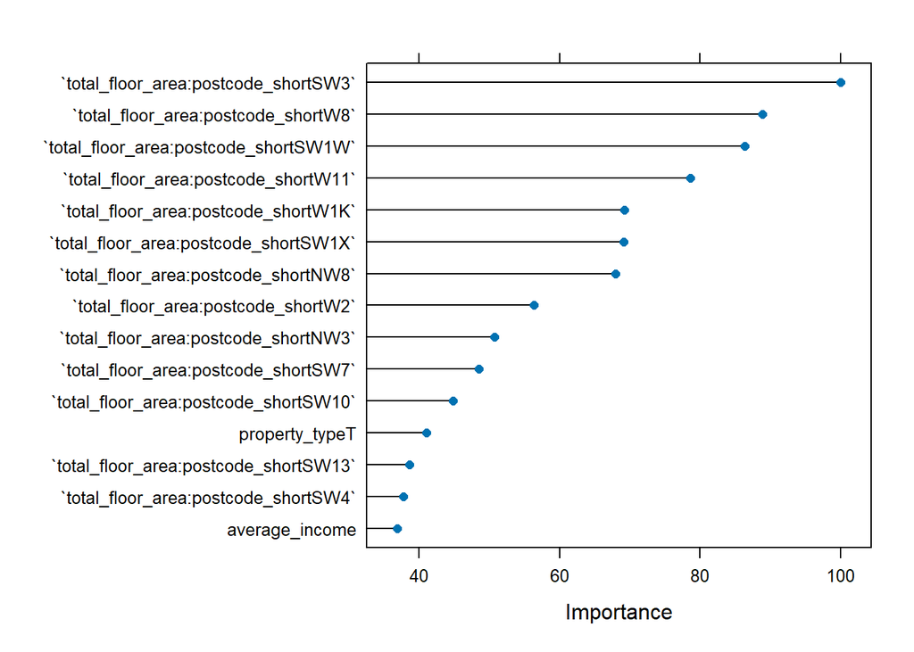

```r
# Calculating variable importance from the linear model
importance <- varImp(model1_lm, scale = TRUE)

# Sorting the importance scores in decreasing order
sorted_importance <- importance$importance[order(-importance$importance$Overall),]

# Selecting the top 15 most important variables
top_15_importance <- head(sorted_importance, 20)

# Plotting the importance of the top 15 variables
plot(varImp(model1_lm, scale = TRUE), top = 15)
```

Upon inspection, the variable importance plot confirms the significance of the interaction variable.

## 5.1 Predict the values in testing and out of sample data

Below I use the predict function to test the performance of the model in testing data and summarise the performance of the linear regression model. The quality of the predictions is then tested on the unseen testing dataset.

```r
# Predicting house prices for the test dataset using the linear model
lr_predictions <- predict(model1_lm, test_data)

# Calculating RMSE (Root Mean Square Error) and R-squared for the test predictions
# RMSE measures the average error between predicted and actual values
# R-squared indicates the proportion of variance explained by the model
lr_results <- data.frame(
  RMSE = RMSE(lr_predictions, test_data$price),
  Rsquare = R2(lr_predictions, test_data$price)
)

# Displaying the performance metrics
lr_results
```

```
##       RMSE   Rsquare
## 1 194002.9 0.8405145
```

```r
# Predicting house prices for out-of-sample data
# This step applies the trained model to new, unseen data
predictions_oos <- predict(model1_lm, london_house_prices_2019_out_of_sample)
```

Achieving an R-squared of 84.1% in the linear regression model is a significant achievement for my project. This high level of explained variance indicates that the model is effectively capturing the key factors that influence London’s house prices. It gives me confidence in the model’s ability to make accurate predictions, which is crucial for guiding investment decisions in the property market. This result reinforces the value of the chosen variables and the model’s approach, suggesting that it can be a reliable tool for understanding and predicting house price trends in London. As I move forward, this robust R-squared value serves as a strong foundation, confirming the model’s potential in practical applications.

# 6 Fit a tree model

```r
# Set seed for reproducibility
set.seed(123)

# Load necessary library for decision trees
library(rpart)

# Define the target variable
target_variable <- "price"

# Fit a decision tree model to the training data
# The formula specifies the target variable and all other variables as predictors
simple_tree_model <- rpart(formula = paste(target_variable, "~ ."), data = train_data)

# Extracting variable importance from the decision tree model
var_importance <- simple_tree_model$variable.importance

# Selecting the top 20 most important variables
top_n_features <- 20
top_features <- sort(var_importance, decreasing = TRUE)[1:top_n_features]
print(names(top_features))
```

```
##  [1] "total_floor_area"             "nearest_station"
##  [3] "postcode_short"               "district"
##  [5] "london_zone"                  "number_habitable_rooms"
##  [7] "co2_emissions_current"        "num_tube_lines"
##  [9] "co2_emissions_potential"      "property_type"
## [11] "longitude"                    "average_income"
## [13] "latitude"                     "energy_consumption_potential"
## [15] NA                             NA
## [17] NA                             NA
## [19] NA                             NA
```

```r
# Training a refined tree model with selected features
model2_tree <- train(
   price ~ total_floor_area + nearest_station + postcode_short + district +
             number_habitable_rooms + london_zone + co2_emissions_current +
             co2_emissions_potential + num_tube_lines + property_type +
             freehold_or_leasehold + longitude + average_income + altitude +
             latitude + windows_energy_eff + total_floor_area:postcode_short + poly(total_floor_area, 2),
  data = train_data,
  method = "rpart",
  trControl = control,
  tuneLength = 10
)
# Viewing model performance metrics
print(model2_tree$results)
```

```
##           cp     RMSE  Rsquared      MAE  RMSESD RsquaredSD    MAESD
## 1 0.01307271 299286.6 0.6848814 167437.0 20680.4 0.06920892 8958.181
## 2 0.01385208 305231.6 0.6736278 172756.9 16735.4 0.05902724 7824.182
##  [ reached 'max' / getOption("max.print") -- omitted 8 rows ]
```

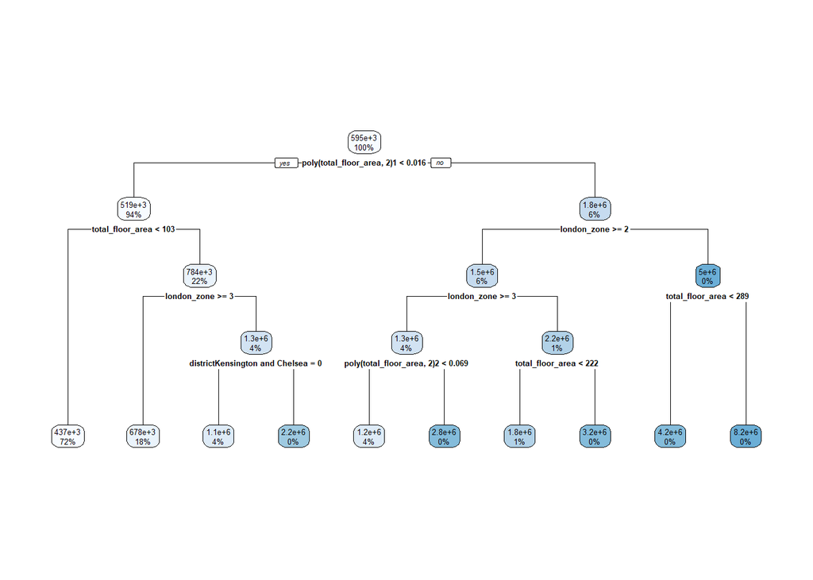

```r
# Visualizing the decision tree
rpart.plot(model2_tree$finalModel)
```

```r
# Visualizing variable importance of the refined tree model
importance <- varImp(model2_tree, scale = TRUE)
print(importance)
```

```
## rpart variable importance
##
##   only 20 most important variables shown (out of 1125)
##
##                                     Overall
## poly(total_floor_area, 2)1          100.000
## total_floor_area                    100.000
## poly(total_floor_area, 2)2           93.084
## london_zone                          73.096
## districtKensington and Chelsea       57.089
## longitude                            45.230
## co2_emissions_potential              33.312
## co2_emissions_current                27.418
## total_floor_area:postcode_shortW8    19.711
## postcode_shortSW3                    17.998
## num_tube_lines                       13.026
## total_floor_area:postcode_shortSW3   11.344
## average_income                        6.667
## nearest_stationvictoria               0.000
## `nearest_stationbruce grove`          0.000
## districtGreenwich                     0.000
## nearest_stationkenley                 0.000
## postcode_shortW10                     0.000
## `total_floor_area:postcode_shortN7`   0.000
## property_typeS                        0.000
```

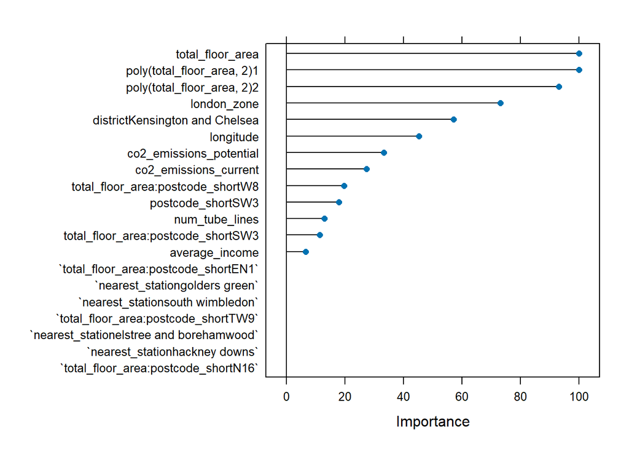

```r
# Plotting the top 20 most important variables
plot(importance, top = 20)
```

Now lets see how well the decision tree model performs on the testing data.

```r
# Predicting house prices on the test data using the decision tree model
predictions_tree <- predict(model2_tree, test_data)

# Creating a data frame to store the performance metrics of the decision tree model
# RMSE (Root Mean Squared Error) measures the average magnitude of the prediction errors
# R-square (Coefficient of Determination) measures the proportion of variance in the dependent variable that is predictable from the independent variables
tr_results <- data.frame(
  RMSE = RMSE(predictions_tree, test_data$price),
  Rsquare = R2(predictions_tree, test_data$price)
)

# Displaying the performance metrics
print(tr_results)
```

```
##       RMSE   Rsquare
## 1 297184.2 0.6230904
```

However, when comparing its performance to the linear regression model, the tree model lagged behind. It achieved an R-squared of 62.3%, which was lower than the linear model’s 84.1%. This difference suggests that the linear model was more adept at interpreting the data, possibly due to its strength in handling linear correlations. The tree model, while insightful, might have struggled with the complexity of the data, highlighting the need for careful model selection based on the data’s characteristics and the project’s goals.

# 7 Other algorithms

## 7.1 XGBoost

XGBoost, or Extreme Gradient Boosting, is a sophisticated machine learning algorithm renowned for its efficiency, flexibility, and high performance, particularly in structured data scenarios like ours. It’s part of a class of ensemble methods known as boosting, where models are built sequentially, and each model attempts to correct the errors of its predecessor. XGBoost stands out for its ability to handle a wide range of data types, its robustness to overfitting, and its capability to efficiently manage missing data and high-dimensional spaces.

```r
# Setting a seed for reproducibility
set.seed(123)

# Loading necessary libraries
library(caret)
library(xgboost)

# Converting factor variables to numeric in the training and test datasets
train_data_xgb <- train_data %>% mutate_if(is.factor, as.numeric)
test_data_xgb <- test_data %>% mutate_if(is.factor, as.numeric)

# Defining training control parameters for cross-validation
train_control <- trainControl(method = "cv", number = 5, verboseIter = TRUE)

# Creating a tuning grid to specify the hyperparameters for XGBoost
tune_grid <- expand.grid(
  nrounds = 3000,                  # Number of boosting rounds
  max_depth = c(5),                # Maximum depth of a tree
  eta = c(0.05),                   # Learning rate
  gamma = c(0.2),                  # Minimum loss reduction for partition
  colsample_bytree = c(0.7),       # Subsample ratio of columns per tree
  min_child_weight = c(3),         # Minimum sum of instance weight needed in a child
  subsample = c(0.8)               # Subsample ratio of the training instances
)

# Training the XGBoost model with the defined parameters
xgb_model <- train(
  price ~ . + total_floor_area:postcode_short + poly(total_floor_area, 2),
  data = train_data_xgb,
  method = "xgbTree",
  trControl = train_control,
  tuneGrid = tune_grid
)
# Generating predictions on test data and evaluating performance
xgb_predictions <- predict(xgb_model, test_data_xgb)
xgb_results <- data.frame(
  RMSE = RMSE(xgb_predictions, test_data$price),
  Rsquare = R2(xgb_predictions, test_data$price)
)

# Displaying the performance metrics
print(xgb_results)
```

```
##       RMSE   Rsquare
## 1 174776.8 0.8678812
```

In this project, I chose XGBoost due to its proven track record in accurately predicting outcomes in complex datasets like the London housing market. The algorithm’s fine-tuning capabilities, through parameters like maximum depth and learning rate, allowed me to tailor the model specifically to our data’s nuances. The model was finetuned through trial and error. Achieving an impressive R-squared of approximately 86.8%, XGBoost has demonstrated its robustness and accuracy in forecasting house prices. This level of performance instills confidence in the model’s predictions, making it an invaluable tool for identifying profitable investment opportunities in the market.

Moving forward, I plan to compare the XGBoost model’s insights with those from a ridge regression model, another powerful technique in predictive modeling. By evaluating these models side by side, I can ensure the most comprehensive analysis of the housing market, leading to more informed and effective investment decisions.

## 7.2 Ridge Regression

Ridge regression, a technique particularly effective for models with a large number of predictor variables, plays a crucial role in this project. By introducing a penalty term (lambda) to the cost function, ridge regression minimizes the impact of less significant variables, thus tackling multicollinearity and overfitting issues that are common in high-dimensional data like ours. In our case, setting alpha to 0 specifically designates the model as a ridge regression, focusing solely on L2 regularization.

```r
# Load necessary libraries
library(caret)
library(glmnet)

# Set training control parameters
# Reduced the number of cross-validation folds from 10 to 5 for efficiency
train_control <- trainControl(method = "cv", number = 5, verboseIter = TRUE)

# Define a tuning grid focusing on Ridge Regression parameters
# Alpha set to 0 signifies a Ridge Regression
tune_grid <- expand.grid(
  alpha = 0,          # Ridge Regression
  lambda = 10000      # Regularization strength
)

# Train the Ridge Regression model
# Including interaction between total_floor_area and postcode_short
# and a polynomial term for total_floor_area to capture non-linear effects
ridge_model <- train(
  price ~ . + total_floor_area:postcode_short + poly(total_floor_area, 2),
  data = train_data,
  method = "glmnet",
  trControl = train_control,
  tuneGrid = tune_grid
)
# Predicting and evaluating the model on the test data
# Calculating RMSE and R-squared metrics
ridge_predictions <- predict(ridge_model, newdata = test_data)
ridge_results <- data.frame(
  RMSE = RMSE(ridge_predictions, test_data$price),
  Rsquare = R2(ridge_predictions, test_data$price)
)

# Displaying the results
print(ridge_results)
```

```
##       RMSE   Rsquare
## 1 180429.9 0.8547924
```

The choice of ridge regression for this project, yielding an R-squared of approximately 85.5%, was strategic. The use of alpha = 0 (ridge regression) over a mixed elastic net approach was found to be more effective, likely due to its simplicity and direct approach in shrinking coefficients, hence enhancing model performance. This decision underscores the importance of model selection tailored to the specific characteristics of the data. In our context, with the goal of predicting London housing prices accurately, ridge regression provides a balance between complexity and predictability, ensuring robust predictions without overfitting the training data.

## 7.3 Random Forest Regression

Following the development of a tree model, the next step in our predictive journey is the implementation of a random forest regression. Random forest, an ensemble learning method, builds upon the concept of decision trees. It creates a ‘forest’ of trees where each tree is trained on a random subset of the data, and the final output is determined by averaging the predictions from all trees. This approach inherently reduces the variance, preventing the overfitting issues often seen in individual tree models.

In our analysis, dealing with the high cardinality of variables like ‘nearest_station’ posed a significant challenge. While such features could add depth to the model, they also complicate it, potentially leading to diminished returns in terms of performance. Consequently, I decided to exclude ‘nearest_station’ from the random forest model. This decision was made to maintain a balance between model complexity and interpretability. On the other hand, retaining ‘postcode_short’ proved beneficial as it significantly contributed to a higher R-squared, indicating its importance in predicting house prices. This strategic choice highlights the importance of feature selection in model building, especially in methods like random forests where the trade-off between complexity and performance is crucial.

```r
# Load necessary libraries
library(caret)
library(ranger)

# Preprocess the training data by removing 'nearest_station' to reduce cardinality
train_data_rf <- train_data %>% select(-nearest_station)

# Apply the same preprocessing to the test data
test_data_rf <- test_data %>% select(-nearest_station)

# Define training control parameters
# Using 5-fold cross-validation for model validation
train_control <- trainControl(method = "cv", number = 5, verboseIter = TRUE)

# Define a tuning grid focusing on key Random Forest parameters
tune_grid <- expand.grid(
  mtry = 21,             # Number of variables randomly sampled as candidates at each split
  splitrule = "variance", # Criteria for splitting nodes
  min.node.size = 5      # Minimum size of terminal nodes
)

# Train the Random Forest model using the 'ranger' package
# The model includes interaction and polynomial terms to capture complex relationships
rf_model <- train(
  price ~ . + postcode_short:total_floor_area + poly(total_floor_area, 2),
  data = train_data_rf,
  method = "ranger",
  trControl = train_control,
  tuneGrid = tune_grid,
  num.trees = 1000       # Number of trees to grow in the forest
)
# Predict and evaluate the model on test data
# Calculating RMSE and R-squared metrics
rf_predictions <- predict(rf_model, test_data_rf)
rf_results <- data.frame(
  RMSE = RMSE(rf_predictions, test_data$price),
  Rsquare = R2(rf_predictions, test_data$price)
)

# Displaying the results
print(rf_results)
```

```
##       RMSE   Rsquare
## 1 192812.7 0.8543371
```

The Random Forest model, achieving an R-squared of approximately 85.4%, demonstrates superior performance compared to the basic tree model. This improvement is attributed to Random Forest’s ability to average multiple decision tree outputs, reducing variance and avoiding overfitting. This enhanced accuracy is crucial for reliable real estate investment decisions in our project. Moreover, the integration of caret and ranger in R effectively manages interaction terms and categorical variables, allowing for a more nuanced and accurate representation of the complex factors influencing London’s housing market.

# 8 Stacking

The stacking method combines the predictive power of multiple algorithms, providing a nuanced understanding of the data. By leveraging the strengths of individual models like XGBoost, Random Forest, Ridge Regression, and Linear Regression, this approach captures a broader range of data patterns and relationships. Stacking in this context is more than just an ensemble technique; it’s a strategic move to enhance the robustness and accuracy of predictions, vital for making informed investment decisions in the dynamic London housing market.

```r
# Load necessary library for glmnet
library(glmnet)

# Generate Predictions for Training Data from each base model
xgb_train_pred <- predict(xgb_model, train_data_xgb)
rf_train_pred <- predict(rf_model, train_data_rf)
ridge_train_pred <- predict(ridge_model, train_data)
lm_train_pred <- predict(model1_lm, train_data)

# Combine Predictions for Training Data into a data frame
combined_train_pred <- data.frame(xgb = xgb_train_pred, rf = rf_train_pred, ridge = ridge_train_pred, lm = lm_train_pred)

# Convert combined predictions to matrix format for glmnet
combined_train_pred_matrix <- as.matrix(combined_train_pred)

# Train the Elastic Net Meta-Model using glmnet
# alpha = 0.5 for equal weight to L1 and L2 regularization. Adjust as necessary.
ridge_model_meta <- cv.glmnet(combined_train_pred_matrix, train_data$price, alpha = 0)

# Find the best lambda value
best_lambda <- ridge_model_meta$lambda.min

# Prepare test data for prediction
xgb_test_pred <- predict(xgb_model, test_data_xgb)
rf_test_pred <- predict(rf_model, test_data_rf)
ridge_test_pred <- predict(ridge_model, test_data)
lm_test_pred <- predict(model1_lm, test_data)

combined_test_pred_matrix <- as.matrix(data.frame(xgb = xgb_test_pred, rf = rf_test_pred, ridge = ridge_test_pred, lm = lm_test_pred))

# Make final predictions using the Elastic Net Meta-Model with the best lambda value
final_predictions_elastic <- predict(ridge_model_meta, newx = combined_test_pred_matrix, s = best_lambda)

# Evaluate the Performance by calculating RMSE and R-squared
stacked_results_elastic <- postResample(pred = final_predictions_elastic, obs = test_data$price)
stacked_results_elastic
```

```
##         RMSE     Rsquared          MAE
## 1.614889e+05 8.836210e-01 8.553322e+04
```

```r
# Display a summary of the Elastic Net Meta-Model
summary(ridge_model_meta)
```

```
##            Length Class  Mode
## lambda     100    -none- numeric
## cvm        100    -none- numeric
## cvsd       100    -none- numeric
## cvup       100    -none- numeric
## cvlo       100    -none- numeric
## nzero      100    -none- numeric
##  [ reached getOption("max.print") -- omitted 6 rows ]
```

The final R-squared value of around 88.4% achieved through stacking signifies a high degree of accuracy in predicting house prices, reflecting the effectiveness of combining multiple models. This enhanced predictive capability is crucial in navigating the complexities of the real estate market, ensuring that investment decisions are grounded in comprehensive data analysis.

# 9 Pick investments

Selecting the top 200 properties for investment is the culmination of this extensive data science endeavor. The chosen algorithm’s predictions guide the identification of properties with the highest potential for profit. This step is not just about applying a model; it’s about translating complex data insights into actionable investment strategies. By meticulously analyzing the estimated profits and market dynamics, this process exemplifies the practical application of data science in real-world decision-making.

```r
# Load necessary libraries
library(dplyr)
library(glmnet)

# Assuming 'oos' is your out-of-sample dataset
numchoose <- 200
oos <- london_house_prices_2019_out_of_sample

# Prepare data for XGBoost and Random Forest models
oos_xgb <- oos %>% mutate_if(is.factor, as.numeric)
oos_rf <- oos %>% select(-nearest_station)

# Generate Predictions for Out-of-Sample Data
lm_oos_pred <- predict(model1_lm, oos)
xgb_oos_pred <- predict(xgb_model, oos_xgb)
ridge_oos_pred <- predict(ridge_model, oos)
rf_oos_pred <- predict(rf_model, oos_rf)

# Combine individual predictions into a matrix
combined_oos_predictions <- as.matrix(data.frame(
  lm = lm_oos_pred,
  xgb = xgb_oos_pred,
  ridge = ridge_oos_pred,
  rf = rf_oos_pred
))

# Use the stacked Ridge Regression model to make final predictions
predicted_price <- predict(ridge_model_meta, newx = combined_oos_predictions, s = best_lambda)

# Calculate estimated profit for each property
estimated_profit <- (predicted_price - oos$asking_price) / oos$asking_price

# Create a temporary dataframe for sorting and selecting top 200 investments
temp_df <- oos
temp_df$estimated_profit <- estimated_profit

# Select the IDs of the top 200 investments
top_200_ids <- temp_df %>%
  arrange(desc(estimated_profit)) %>%
  head(numchoose) %>%
  pull(ID)

# Add a 'buy' column to the original 'oos' dataframe
oos$buy <- ifelse(oos$ID %in% top_200_ids, 1, 0)

# Write the modified 'oos' dataframe to a CSV file
write.csv(oos, "Thompson_Daniel.csv", row.names = FALSE)
```

Concluding this project, the journey from data exploration to investment selection demonstrates the transformative power of data science in the real estate domain. The insights gained and the methodology applied here underscore the importance of rigorous data analysis in guiding strategic investment decisions.